# Pertemuan 2

Angel Martha Pradina Pangaribuan

2023-08-23

## Library / Packages

*Package* R yang akan digunakan pada perkuliahan Analisis Deret Waktu sesi UTS adalah: `forecast`, `graphics`, `TTR`, `TSA` . Jika *package* tersebut belum ada, silakan install terlebih dahulu.

```r
library(TTR)
library(TSA)
```

```r
library(graphics)
library(forecast)
library(imputeTS)
library(ggplot2)
```

## Impor Data

```r
#install.packages("rio") #install jika belum ada
library(rio)
setwd("C:\\Users\\Angel Martha\\Downloads")
goto<-read.csv("GOTO.JK.csv",sep=",")
```

## Eksplorasi Data

Melihat data menggunakan fungsi `View()`, struktur data menggunakan fungsi `str()`, dan dimensi data menggunakan fungsi `dim()`.

```r
View(goto)
str(goto)
```

```
## 'data.frame':    242 obs. of  7 variables:
##  $ Tanggal  : chr  "2022-09-05" "2022-09-06" "2022-09-07" "2022-09-08" ...
##  $ Open     : num  284 286 282 286 288 284 280 272 274 266 ...
##  $ High     : num  292 290 294 292 290 286 284 278 276 266 ...
##  $ Low      : num  280 282 280 284 278 276 276 268 266 248 ...
##  $ Close    : num  282 282 282 286 282 278 276 272 266 248 ...
##  $ Adj.Close: num  282 282 282 286 282 278 276 272 266 248 ...
##  $ Volume   : num  5.52e+08 4.19e+08 1.08e+09 1.30e+09 7.23e+08 ...
```

```r
dim(goto)
```

```
## [1] 242   7
```

#Mengubah data agar terbaca sebagai data deret waktu dengan fungsi `ts()` .

```r
goto.ts <- ts(goto$Close)
```

#Menampilkan ringkasan data

```r
summary(goto.ts)
```

```
##    Min. 1st Qu.  Median    Mean 3rd Qu.    Max.
##    82.0   106.0   115.5   138.6   170.2   286.0
```

#Membuat plot data deret waktu

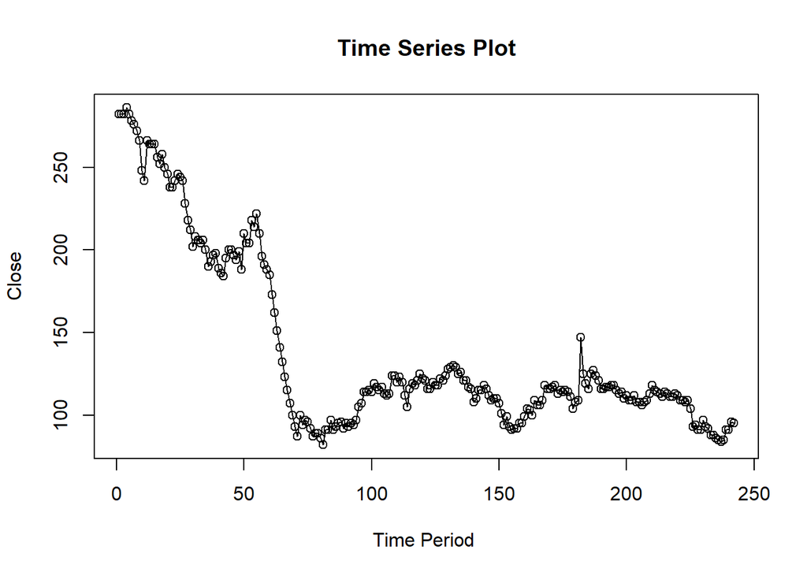

```r
ts.plot(goto.ts, xlab="Time Period ", ylab="Close",
        main = "Time Series Plot")
points(goto.ts)
```

## Single Moving Average & Double Moving Average

### Pembagian Data

Pembagian data latih dan data uji dilakukan dengan perbandingan 80% data latih dan 20% data uji.

```r
#membagi data latih dan data uji
training_ma <- goto[1:190,]
testing_ma <- goto[191:242,]
train_ma.ts <- ts(training_ma$Close)
test_ma.ts <- ts(testing_ma$Close)
```

### Eksplorasi Data

Eksplorasi data dilakukan pada keseluruhan data, data latih serta data uji menggunakan plot data deret waktu.

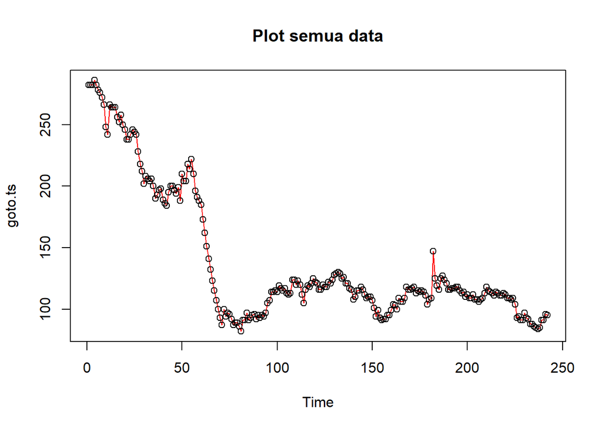

```r
#eksplorasi keseluruhan data
plot(goto.ts, col="red",main="Plot semua data")
points(goto.ts)
```

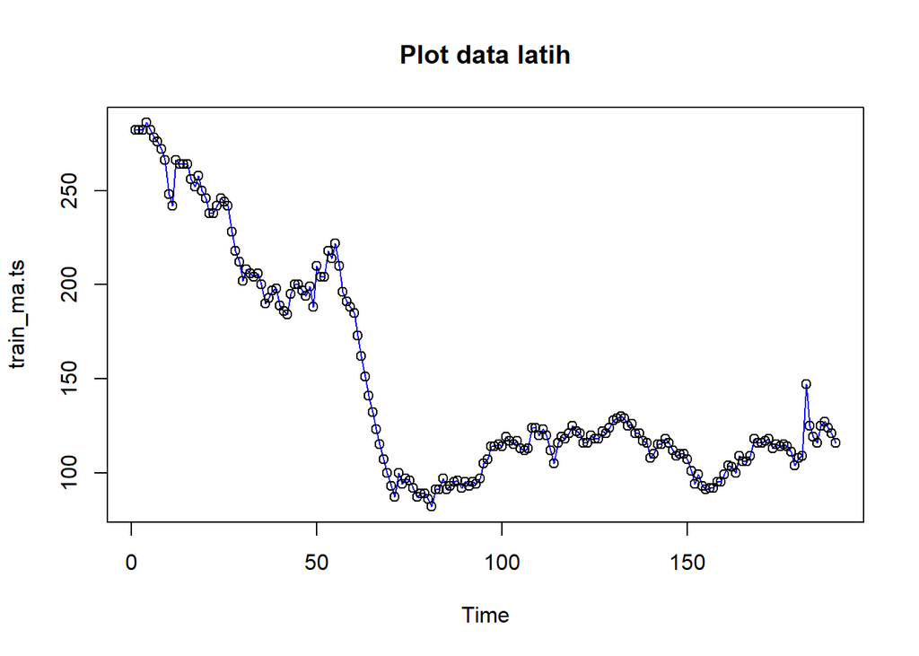

```r
#eksplorasi data latih
plot(train_ma.ts, col="blue",main="Plot data latih")
points(train_ma.ts)
```

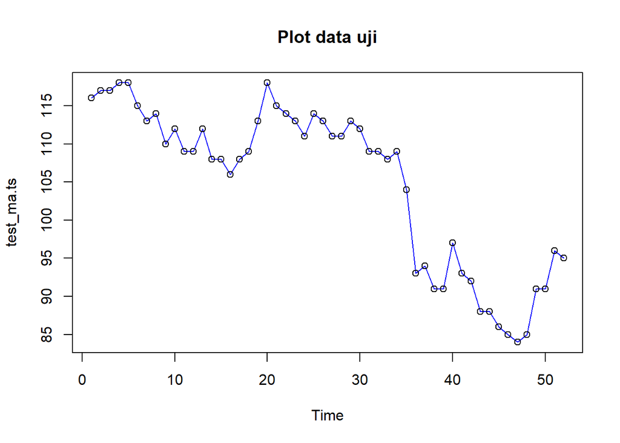

```r
#eksplorasi data uji
plot(test_ma.ts, col="blue",main="Plot data uji")
points(test_ma.ts)
```

## Single Moving Average (SMA)

Ide dasar dari Single Moving Average (SMA) adalah data suatu periode dipengaruhi oleh data periode sebelumnya. Metode pemulusan ini cocok digunakan untuk pola data stasioner atau konstan. Prinsip dasar metode pemulusan ini adalah data pemulusan pada periode ke-t merupakan rata rata dari m buah data pada periode ke-t hingga periode ke (t-m+1). Data pemulusan pada periode ke-t selanjutnya digunakan sebagai nilai peramalan pada periode ke t+1

Pemulusan menggunakan metode SMA dilakukan dengan fungsi `SMA()`. Dalam hal ini akan dilakukan pemulusan dengan parameter `m=5`.

```r
goto.sma<-SMA(train_ma.ts, n=5)
goto.sma
```

```
## Time Series:
## Start = 1
## End = 190
## Frequency = 1
##   [1]    NA    NA    NA    NA 282.8 282.0 280.8 278.8 274.8 268.0 260.8 258.8
##  [13] 257.2 256.8 260.0 262.8 260.0 258.8 256.0 252.4 248.8 246.0 242.8 242.0
##  [25] 241.6 242.4 240.4 235.6 228.8 220.4 213.6 209.2 206.4 205.2 204.8 201.2
##  [37] 198.6 197.2 195.6 193.4 192.6 190.8 190.4 190.8 193.0 195.2 197.2 198.0
##  [49] 195.6 197.6 199.0 201.0 204.8 210.0 212.4 213.6 212.0 206.6 201.4 194.0
##  [61] 186.6 179.8 171.8 162.4 151.8 141.8 132.4 123.6 115.4 107.6 100.4  97.4
##  [73]  94.8  94.2  94.8  95.8  93.2  92.2  90.6  88.6  86.6  87.4  87.8  89.4
##  [85]  90.4  92.6  93.4  94.4  93.4  94.2  94.2  94.2  93.8  94.8  96.8  99.6
##  [97] 103.4 107.4 111.0 112.8 115.2 115.8 116.0 116.4 116.2 114.8 114.0 115.8
## [109] 117.2 118.6 120.8 122.2 119.8 116.0 115.2 114.4 114.0 115.8 119.8 121.0
## [121] 121.4 121.0 120.0 119.0 118.2 117.6 118.8 119.8 120.6 122.6 124.8 126.4
## [133] 128.0 128.2 127.8 126.2 124.4 122.0 120.2 116.6 114.4 113.2 112.8 113.2
## [145] 114.8 115.2 114.0 113.0 111.4 109.6 107.4 104.4 102.2  98.8  95.6  93.8
## [157]  93.4  92.6  93.0  94.6  97.0  99.2 100.2 103.0 104.4 104.8 106.0 109.6
## [169] 111.0 113.0 115.2 117.0 116.0 115.8 115.4 115.0 114.2 113.8 111.6 110.4
## [181] 109.2 115.8 118.6 121.6 123.2 126.4 122.4 122.2 122.6 122.6
```

Data pemulusan pada periode ke-t selanjutnya digunakan sebagai nilai peramalan pada periode ke t+1 sehingga hasil peramalan 1 periode kedepan adalah sebagai berikut.

```r
goto.ramal<-c(NA,goto.sma)
goto.ramal #forecast 1 periode ke depan
```

```
##   [1]    NA    NA    NA    NA    NA 282.8 282.0 280.8 278.8 274.8 268.0 260.8
##  [13] 258.8 257.2 256.8 260.0 262.8 260.0 258.8 256.0 252.4 248.8 246.0 242.8
##  [25] 242.0 241.6 242.4 240.4 235.6 228.8 220.4 213.6 209.2 206.4 205.2 204.8
##  [37] 201.2 198.6 197.2 195.6 193.4 192.6 190.8 190.4 190.8 193.0 195.2 197.2
##  [49] 198.0 195.6 197.6 199.0 201.0 204.8 210.0 212.4 213.6 212.0 206.6 201.4
##  [61] 194.0 186.6 179.8 171.8 162.4 151.8 141.8 132.4 123.6 115.4 107.6 100.4
##  [73]  97.4  94.8  94.2  94.8  95.8  93.2  92.2  90.6  88.6  86.6  87.4  87.8
##  [85]  89.4  90.4  92.6  93.4  94.4  93.4  94.2  94.2  94.2  93.8  94.8  96.8
##  [97]  99.6 103.4 107.4 111.0 112.8 115.2 115.8 116.0 116.4 116.2 114.8 114.0
## [109] 115.8 117.2 118.6 120.8 122.2 119.8 116.0 115.2 114.4 114.0 115.8 119.8
## [121] 121.0 121.4 121.0 120.0 119.0 118.2 117.6 118.8 119.8 120.6 122.6 124.8
## [133] 126.4 128.0 128.2 127.8 126.2 124.4 122.0 120.2 116.6 114.4 113.2 112.8
## [145] 113.2 114.8 115.2 114.0 113.0 111.4 109.6 107.4 104.4 102.2  98.8  95.6
## [157]  93.8  93.4  92.6  93.0  94.6  97.0  99.2 100.2 103.0 104.4 104.8 106.0
## [169] 109.6 111.0 113.0 115.2 117.0 116.0 115.8 115.4 115.0 114.2 113.8 111.6
## [181] 110.4 109.2 115.8 118.6 121.6 123.2 126.4 122.4 122.2 122.6 122.6
```

```r
goto.gab<-cbind(aktual=c(train_ma.ts,rep(NA,51)),pemulusan=c(goto.sma,rep(NA,51)),ramalan=c(goto.ramal,rep(goto.ramal[length(goto.ramal)],52)))
goto.gab #forecast 24 periode ke depan
```

```
##        aktual pemulusan ramalan
##   [1,]    282        NA      NA
##   [2,]    282        NA      NA
##   [3,]    282        NA      NA
##   [4,]    286        NA      NA
##   [5,]    282     282.8      NA
##   [6,]    278     282.0   282.8
##   [7,]    276     280.8   282.0
##   [8,]    272     278.8   280.8
##   [9,]    266     274.8   278.8
##  [10,]    248     268.0   274.8
##  [11,]    242     260.8   268.0
##  [12,]    266     258.8   260.8
##  [13,]    264     257.2   258.8
##  [14,]    264     256.8   257.2
```

[output cut: 229 more lines]

Adapun plot data deret waktu dari hasil peramalan yang dilakukan adalah sebagai berikut.

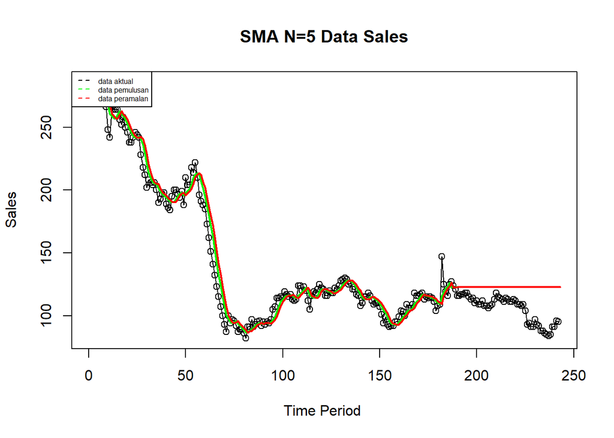

```r
ts.plot(goto.ts, xlab="Time Period ", ylab="Sales", main= "SMA N=5 Data Sales")
points(goto.ts)
lines(goto.gab[,2],col="green",lwd=2)
lines(goto.gab[,3],col="red",lwd=2)
legend("topleft",c("data aktual","data pemulusan","data peramalan"), lty=8, col=c("black","green","red"), cex=0.5)
```

Selanjutnya perhitungan akurasi dilakukan dengan ukuran akurasi *Sum Squares Error* (SSE), *Mean Square Error* (MSE) dan *Mean Absolute Percentage Error* (MAPE). Perhitungan akurasi dilakukan baik pada data latih maupun pada data uji.

```r
#Menghitung nilai keakuratan data latih
error_train.sma = train_ma.ts-goto.ramal[1:length(train_ma.ts)]
SSE_train.sma = sum(error_train.sma[6:length(train_ma.ts)]^2)
MSE_train.sma = mean(error_train.sma[6:length(train_ma.ts)]^2)
MAPE_train.sma = mean(abs((error_train.sma[6:length(train_ma.ts)]/train_ma.ts[6:length(train_ma.ts)])*100))

akurasi_train.sma <- matrix(c(SSE_train.sma, MSE_train.sma, MAPE_train.sma))
row.names(akurasi_train.sma)<- c("SSE", "MSE", "MAPE")
colnames(akurasi_train.sma) <- c("Akurasi m = 5")
akurasi_train.sma
```

```
##      Akurasi m = 5
## SSE   20259.240000
## MSE     109.509405
## MAPE      5.344456
```

```r
#Menghitung nilai keakuratan data uji
error_test.sma = test_ma.ts-goto.gab[190:241,3]
SSE_test.sma = sum(error_test.sma^2)
MSE_test.sma = mean(error_test.sma^2)
MAPE_test.sma = mean(abs((error_test.sma/test_ma.ts*100)))

akurasi_test.sma <- matrix(c(SSE_test.sma, MSE_test.sma, MAPE_test.sma))
row.names(akurasi_test.sma)<- c("SSE", "MSE", "MAPE")
colnames(akurasi_test.sma) <- c("Akurasi m = 5")
akurasi_test.sma
```

```
##      Akurasi m = 5
## SSE    22128.32000
## MSE      425.54462
## MAPE      18.15342
```

### Double Moving Average (DMA)

Metode pemulusan Double Moving Average (DMA) pada dasarnya mirip dengan SMA. Namun demikian, metode ini lebih cocok digunakan untuk pola data trend. Proses pemulusan dengan rata rata dalam metode ini dilakukan sebanyak 2 kali.

```r
dma <- SMA(goto.sma, n = 5)
At <- 2*goto.sma - dma
Bt <- 2/(5-1)*(goto.sma - dma)
goto.dma<- At+Bt
goto.ramal2<- c(NA, goto.dma)

t = 1:51
f = c()

for (i in t) {
  f[i] = At[length(At)] + Bt[length(Bt)]*(i)
}

goto.gab2 <- cbind(aktual = c(train_ma.ts,rep(NA,51)), pemulusan1 = c(goto.sma,rep(NA,51)),pemulusan2 = c(goto.dma, rep(NA,51)),At = c(At, rep(NA,51)), Bt = c(Bt,rep(NA,51)),ramalan = c(goto.ramal2, f[-1]))
goto.gab2
```

```
##        aktual pemulusan1 pemulusan2     At            Bt ramalan
##   [1,]    282         NA         NA     NA            NA      NA
##   [2,]    282         NA         NA     NA            NA      NA
##   [3,]    282         NA         NA     NA            NA      NA
##   [4,]    286         NA         NA     NA            NA      NA
##   [5,]    282      282.8         NA     NA            NA      NA
##   [6,]    278      282.0         NA     NA            NA      NA
##   [7,]    276      280.8         NA     NA            NA      NA
##   [8,]    272      278.8         NA     NA            NA      NA
##   [9,]    266      274.8     267.24 269.76 -2.520000e+00      NA
##  [10,]    248      268.0     254.68 259.12 -4.440000e+00  267.24
##  [11,]    242      260.8     243.04 248.96 -5.920000e+00  254.68
##  [12,]    266      258.8     244.64 249.36 -4.720000e+00  243.04
##  [13,]    264      257.2     247.12 250.48 -3.360000e+00  244.64
##  [14,]    264      256.8     251.52 253.28 -1.760000e+00  247.12
```

[output cut: 227 more lines]

Hasil pemulusan menggunakan metode DMA divisualisasikan sebagai berikut

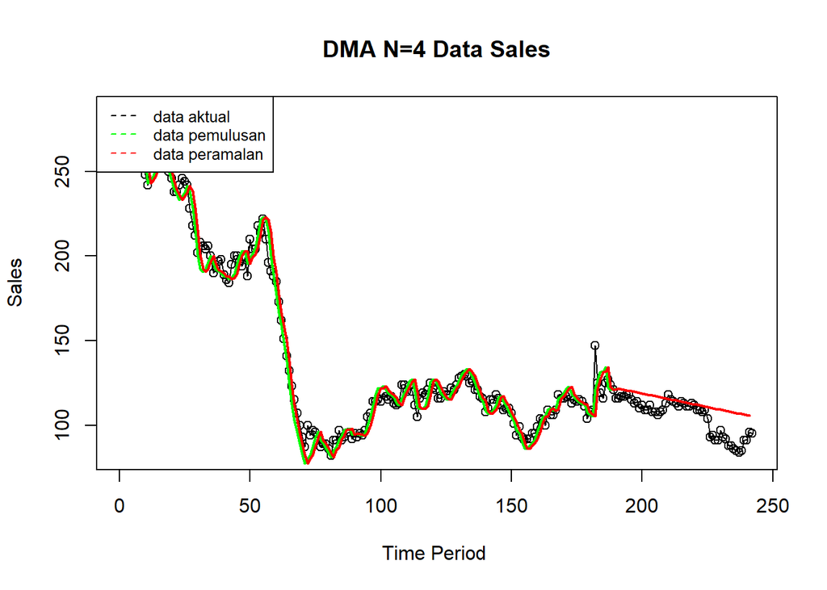

```r
ts.plot(goto.ts, xlab="Time Period ", ylab="Sales", main= "DMA N=4 Data Sales")
points(goto.ts)
lines(goto.gab2[,3],col="green",lwd=2)
lines(goto.gab2[,6],col="red",lwd=2)
legend("topleft",c("data aktual","data pemulusan","data peramalan"), lty=8, col=c("black","green","red"), cex=0.8)
```

Selanjutnya perhitungan akurasi dilakukan baik pada data latih maupun data uji. Perhitungan akurasi dilakukan dengan ukuran akurasi SSE, MSE dan MAPE.

```r
#Menghitung nilai keakuratan data latih
error_train.dma = train_ma.ts-goto.ramal2[1:length(train_ma.ts)]
SSE_train.dma = sum(error_train.dma[10:length(train_ma.ts)]^2)
MSE_train.dma = mean(error_train.dma[10:length(train_ma.ts)]^2)
MAPE_train.dma = mean(abs((error_train.dma[10:length(train_ma.ts)]/train_ma.ts[10:length(train_ma.ts)])*100))

akurasi_train.dma <- matrix(c(SSE_train.dma, MSE_train.dma, MAPE_train.dma))
row.names(akurasi_train.dma)<- c("SSE", "MSE", "MAPE")
colnames(akurasi_train.dma) <- c("Akurasi m = 5")
akurasi_train.dma
```

```
##      Akurasi m = 5
## SSE    13870.88200
## MSE       76.63471
## MAPE       4.61488
```

Perhitungan akurasi pada data latih menggunakan nilai MAPE menghasilkan nilai MAPE yang kurang dari 10% sehingga dikategorikan sangat baik. Selanjutnya, perhitungan nilai akurasi dilakukan pada data uji.

```r
#Menghitung nilai keakuratan data uji
error_test.dma = test_ma.ts-goto.gab2[190:241,6]
SSE_test.dma = sum(error_test.dma^2)
MSE_test.dma = mean(error_test.dma^2)
MAPE_test.dma = mean(abs((error_test.dma/test_ma.ts*100)))

akurasi_test.dma <- matrix(c(SSE_test.dma, MSE_test.dma, MAPE_test.dma))
row.names(akurasi_test.dma)<- c("SSE", "MSE", "MAPE")
colnames(akurasi_test.dma) <- c("Akurasi m = 4")
akurasi_test.dma
```

```
##      Akurasi m = 4
## SSE    6671.781200
## MSE     128.303485
## MAPE      9.310808
```

## Single Exponential Smoothing & Double Exponential Smoothing

Metode *Exponential Smoothing* adalah metode pemulusan dengan melakukan pembobotan menurun secara eksponensial. Nilai yang lebih baru diberi bobot yang lebih besar dari nilai terdahulu. Terdapat satu atau lebih parameter pemulusan yang ditentukan secara eksplisit, dan hasil pemilihan parameter tersebut akan menentukan bobot yang akan diberikan pada nilai pengamatan. Ada dua macam model, yaitu model tunggal dan ganda.

### Pembagian Data

Pembagian data latih dan data uji dilakukan dengan perbandingan 80% data latih dan 20% data uji.

```r
#membagi training dan testing
training<-goto[1:190,]
testing<-goto[191:242,]
train.ts <- ts(training$Close)
test.ts <- ts(testing$Close)
```

### Eksplorasi

Eksplorasi dilakukan dengan membuat plot data deret waktu untuk keseluruhan data, data latih, dan data uji.

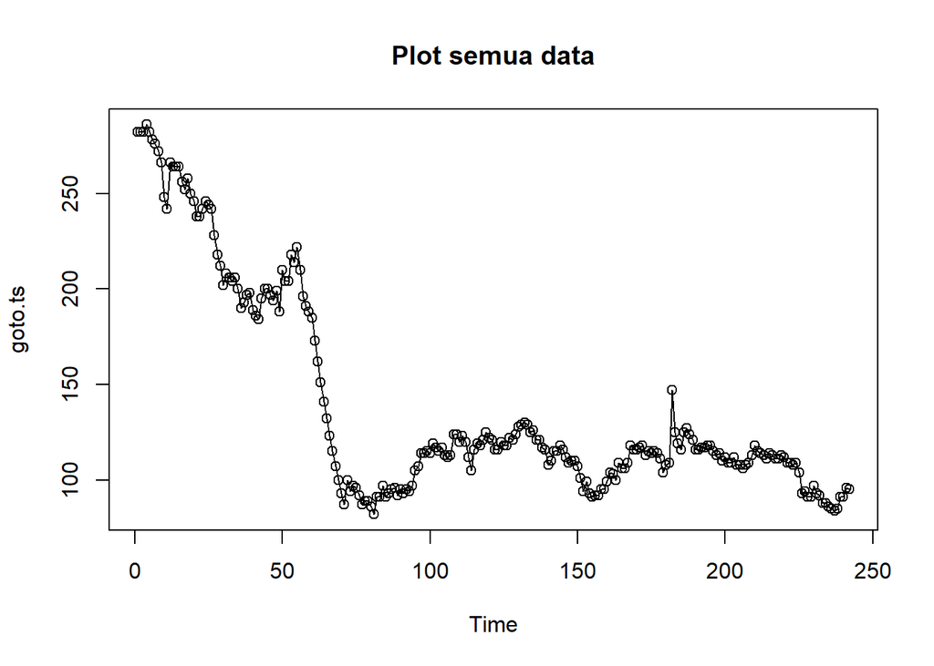

```r
#eksplorasi data
plot(goto.ts, col="black",main="Plot semua data")
points(goto.ts)
```

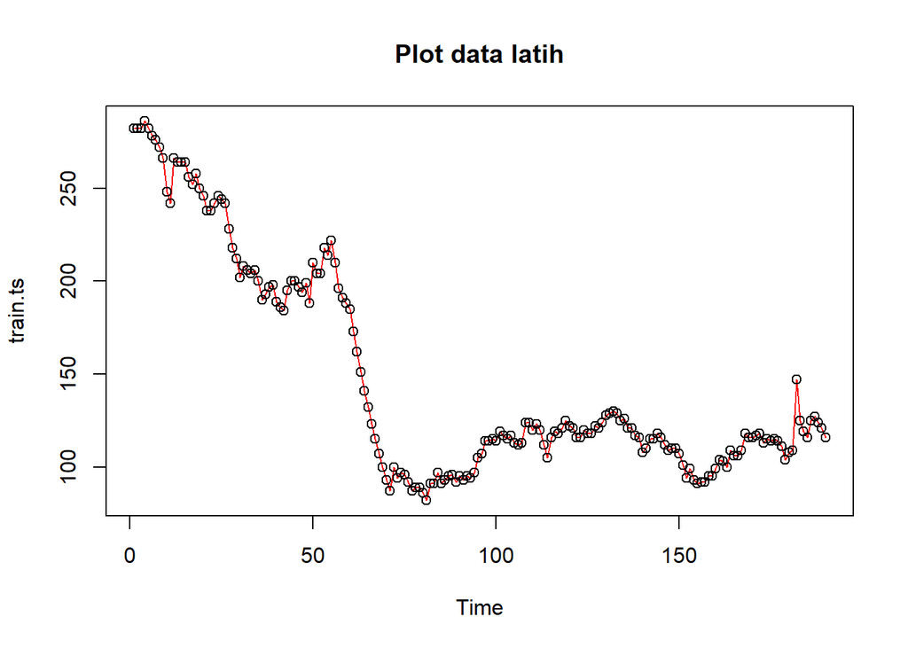

```r
plot(train.ts, col="red",main="Plot data latih")
points(train.ts)
```

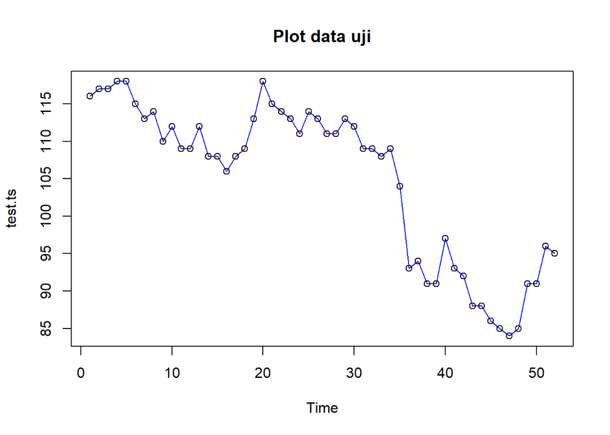

```r
plot(test.ts, col="blue",main="Plot data uji")
points(test.ts)
```

### SES

Single Exponential Smoothing merupakan metode pemulusan yang tepat digunakan untuk data dengan pola stasioner atau konstan.

Nilai pemulusan pada periode ke-t didapat dari persamaan:

$$\tilde{y}_T=\lambda y_t+(1-\lambda)\tilde{y}_{T-1}$$

Nilai parameter $\lambda$ adalah nilai antara 0 dan 1.

Nilai pemulusan periode ke-t bertindak sebagai nilai ramalan pada periode ke-$(T+\tau)$.

$$\tilde{y}_{T+\tau}(T)=\tilde{y}_T$$

Pemulusan dengan metode SES dapat dilakukan dengan dua fungsi dari *packages* berbeda, yaitu (1) fungsi `ses()` dari *packages* `forecast` dan (2) fungsi `HoltWinters` dari *packages* `stats` .

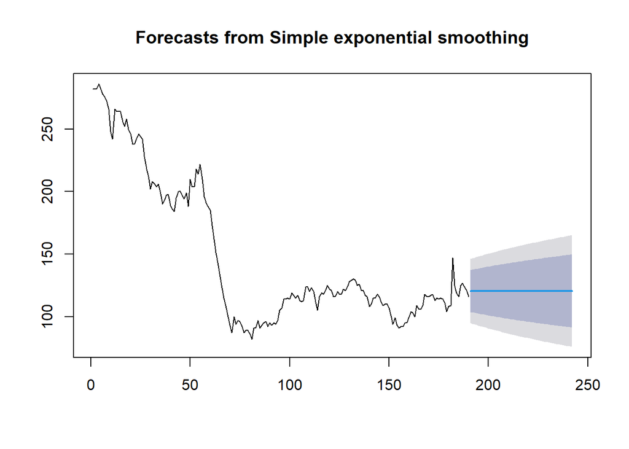

```r
#Cara 1 (fungsi ses)
ses.1 <- ses(train.ts, h = 52, alpha = 0.2)
plot(ses.1)
```

```r
ses.1
```

```
##     Point Forecast     Lo 80    Hi 80    Lo 95    Hi 95
## 191       120.5075 103.77135 137.2437 94.91174 146.1034
## 192       120.5075 103.43990 137.5752 94.40484 146.6103
## 193       120.5075 103.11478 137.9003 93.90760 147.1075
## 194       120.5075 102.79562 138.2195 93.41949 147.5956
## 195       120.5075 102.48211 138.5330 92.94002 148.0751
## 196       120.5075 102.17396 138.8411 92.46874 148.5463
## 197       120.5075 101.87090 139.1442 92.00526 149.0098
## 198       120.5075 101.57270 139.4424 91.54919 149.4659
## 199       120.5075 101.27912 139.7360 91.10020 149.9149
## 200       120.5075 100.98995 140.0251 90.65796 150.3571
## 201       120.5075 100.70501 140.3101 90.22218 150.7929
## 202       120.5075 100.42411 140.5910 89.79258 151.2225
## 203       120.5075 100.14708 140.8680 89.36890 151.6462
## 204       120.5075  99.87377 141.1413 88.95091 152.0642
```

[output cut: 38 more lines]

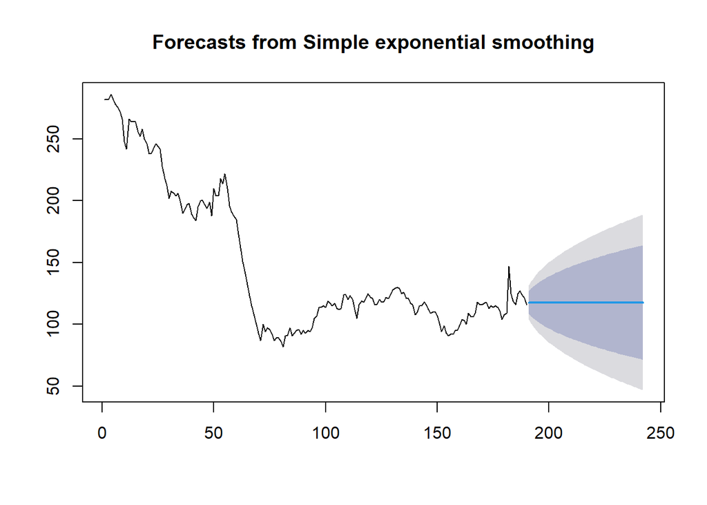

```r
ses.2<- ses(train.ts, h = 52, alpha = 0.7)
plot(ses.2)
```

```r
ses.2
```

```
##     Point Forecast     Lo 80    Hi 80     Lo 95    Hi 95
## 191       117.8171 108.71893 126.9153 103.90265 131.7316
## 192       117.8171 106.71137 128.9229 100.83234 134.8019
## 193       117.8171 105.01484 130.6194  98.23772 137.3965
## 194       117.8171 103.51820 132.1160  95.94881 139.6854
## 195       117.8171 102.16401 133.4702  93.87776 141.7565
## 196       117.8171 100.91799 134.7162  91.97213 143.6621
## 197       117.8171  99.75774 135.8765  90.19768 145.4366
## 198       117.8171  98.66766 136.9666  88.53054 147.1037
## 199       117.8171  97.63637 137.9979  86.95333 148.6809
## 200       117.8171  96.65528 138.9790  85.45288 150.1813
## 201       117.8171  95.71771 139.9165  84.01898 151.6152
## 202       117.8171  94.81832 140.8159  82.64349 152.9907
## 203       117.8171  93.95280 141.6814  81.31980 154.3144
## 204       117.8171  93.11760 142.5166  80.04247 155.5918
```

[output cut: 38 more lines]

Untuk mendapatkan gambar hasil pemulusan pada data latih dengan fungsi `ses()` , perlu digunakan fungsi `autoplot()` dan `autolayer()` dari *library packages* `ggplot2` .

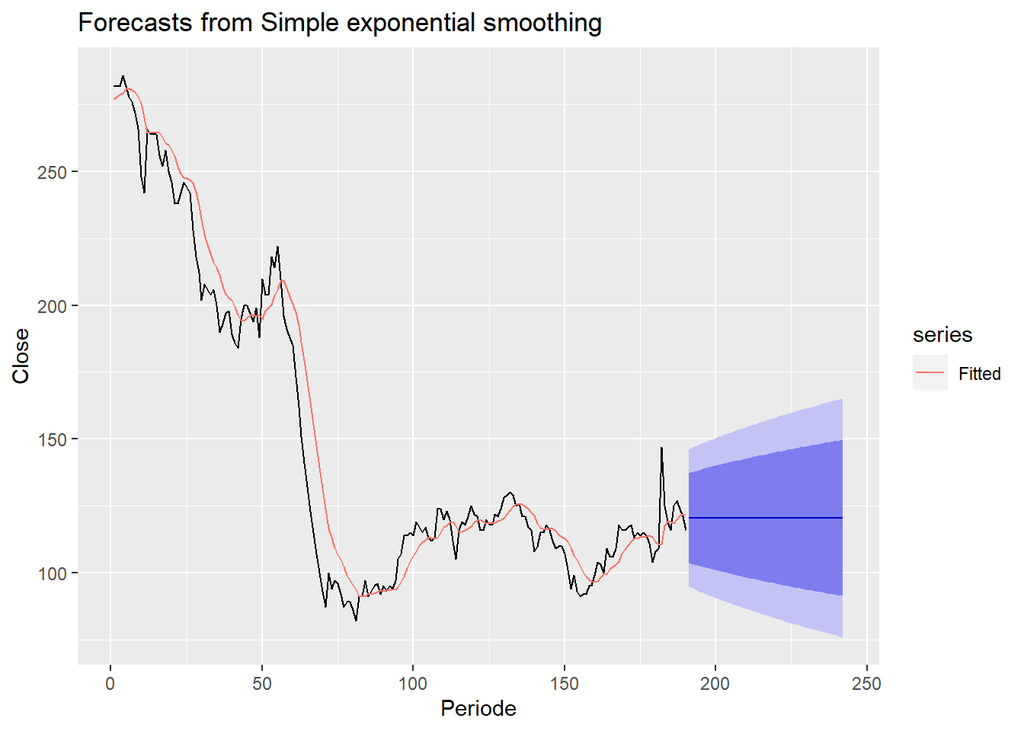

```r
autoplot(ses.1) +
  autolayer(fitted(ses.1), series="Fitted") +
  ylab("Close") + xlab("Periode")
```

Pada fungsi `ses()` , terdapat beberapa argumen yang umum digunakan, yaitu nilia `y` , `gamma` , `beta` , `alpha` , dan `h` .

Nilai `y` adalah nilai data deret waktu, `gamma` adalah parameter pemulusan untuk komponen musiman, `beta` adalah parameter pemulusan untuk tren, dan `alpha` adalah parameter pemulusan untuk stasioner, serta `h` adalah banyaknya periode yang akan diramalkan.

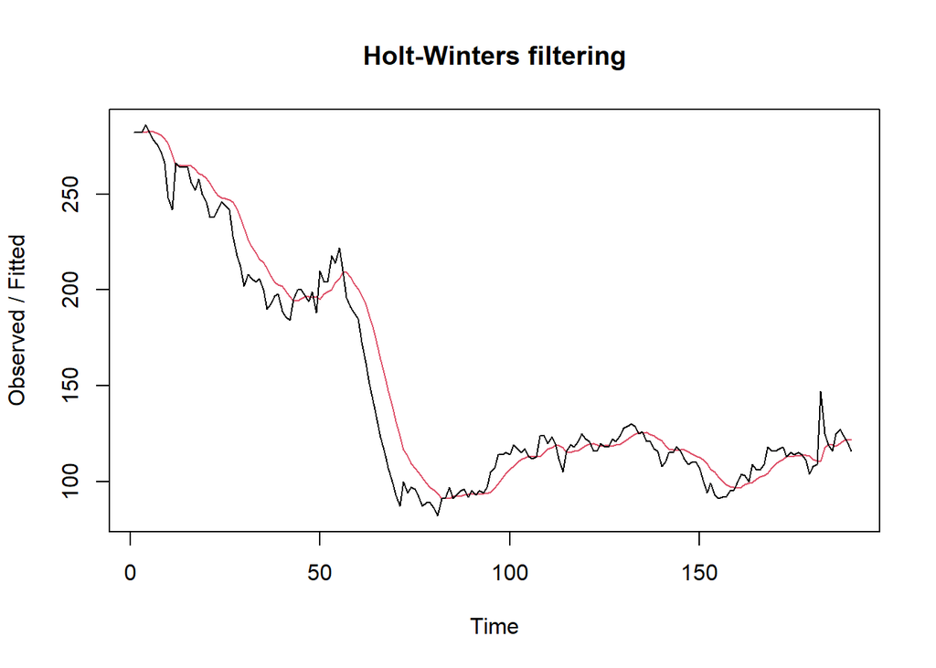

```r
#Cara 2 (fungsi Holtwinter)
ses1<- HoltWinters(train.ts, gamma = FALSE, beta = FALSE, alpha = 0.2)
plot(ses1)
```

```r
#ramalan
ramalan1<- forecast(ses1, h=52)
ramalan1
```

```
##     Point Forecast     Lo 80    Hi 80    Lo 95    Hi 95
## 191       120.5075 104.67800 136.3371 96.29834 144.7168
## 192       120.5075 104.36451 136.6506 95.81890 145.1962
## 193       120.5075 104.05700 136.9581 95.34860 145.6665
## 194       120.5075 103.75513 137.2600 94.88693 146.1282
## 195       120.5075 103.45860 137.5565 94.43343 146.5817
## 196       120.5075 103.16714 137.8479 93.98769 147.0274
## 197       120.5075 102.88051 138.1346 93.54931 147.4658
## 198       120.5075 102.59846 138.4166 93.11796 147.8971
## 199       120.5075 102.32078 138.6943 92.69329 148.3218
## 200       120.5075 102.04728 138.9678 92.27500 148.7401
## 201       120.5075 101.77777 139.2373 91.86283 149.1523
## 202       120.5075 101.51209 139.5030 91.45650 149.5586
## 203       120.5075 101.25007 139.7650 91.05577 149.9593
## 204       120.5075 100.99157 140.0235 90.66043 150.3547
```

[output cut: 38 more lines]

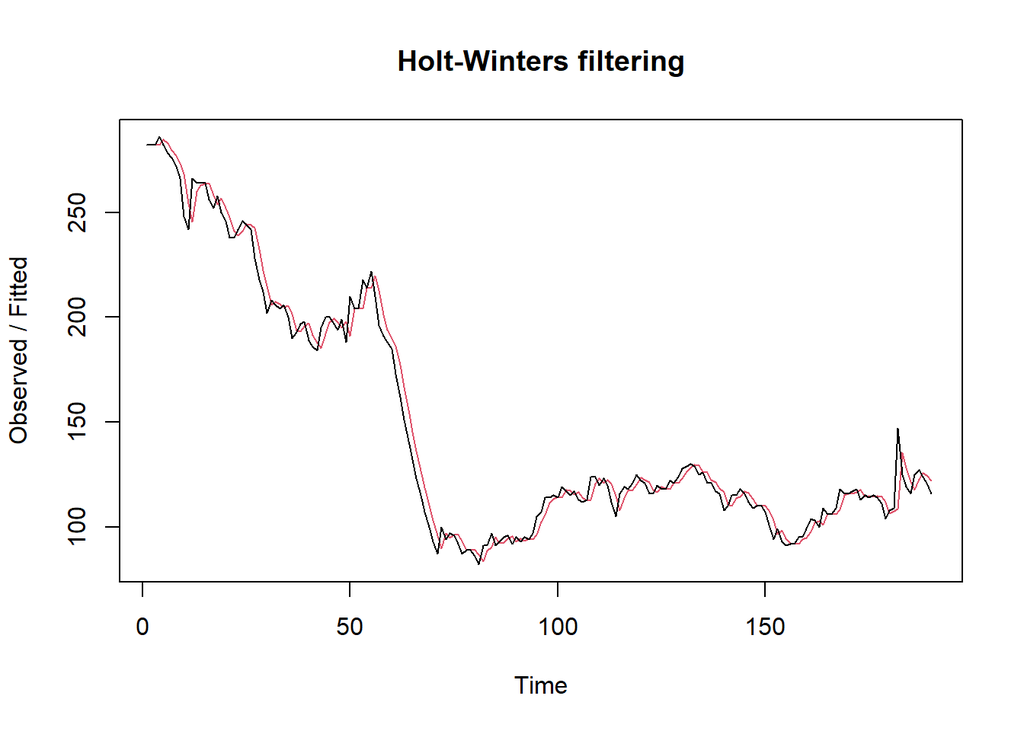

```r
ses2<- HoltWinters(train.ts, gamma = FALSE, beta = FALSE, alpha = 0.7)
plot(ses2)
```

```r
#ramalan
ramalan2<- forecast(ses2, h=52)
ramalan2
```

```
##     Point Forecast     Lo 80    Hi 80     Lo 95    Hi 95
## 191       117.8171 108.85976 126.7745 104.11803 131.5162
## 192       117.8171 106.88327 128.7510 101.09525 134.5390
## 193       117.8171 105.21300 130.4212  98.54079 137.0934
## 194       117.8171 103.73953 131.8947  96.28731 139.3469
## 195       117.8171 102.40630 133.2279  94.24831 141.3859
## 196       117.8171 101.17957 134.4547  92.37219 143.2620
## 197       117.8171 100.03728 135.5970  90.62520 145.0090
## 198       117.8171  98.96407 136.6702  88.98387 146.6504
## 199       117.8171  97.94875 137.6855  87.43106 148.2032
## 200       117.8171  96.98284 138.6514  85.95385 149.6804
## 201       117.8171  96.05978 139.5745  84.54214 151.0921
## 202       117.8171  95.17432 140.4599  83.18794 152.4463
## 203       117.8171  94.32220 141.3120  81.88474 153.7495
## 204       117.8171  93.49992 142.1343  80.62718 155.0071
```

[output cut: 38 more lines]

Fungsi `HoltWinters` memiliki argumen yang sama dengan fungsi `ses()` . Argumen-argumen kedua fungsi dapat dilihat lebih lanjut dengan `?ses()` atau `?HoltWinters` .

Nilai parameter $\alpha$ dari kedua fungsi dapat dioptimalkan menyesuaikan dari *error*-nya paling minimumnya. Caranya adalah dengan membuat parameter $\alpha =$ `NULL` .

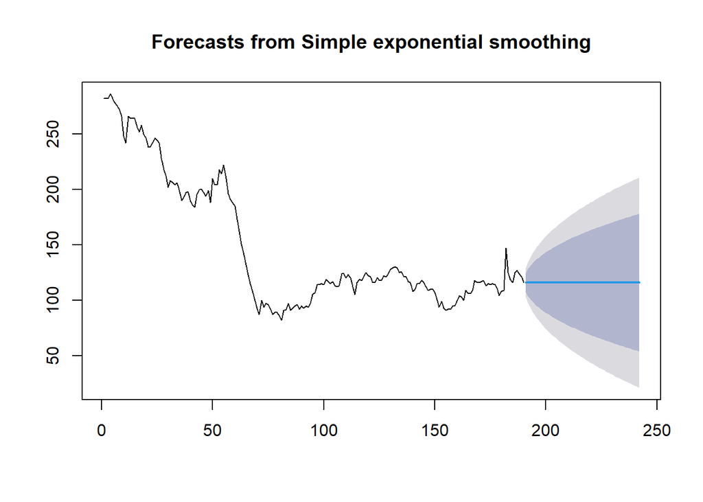

```r
#SES
ses.opt <- ses(train.ts, h = 52, alpha = NULL)
plot(ses.opt)
```

```r
ses.opt
```

```
##     Point Forecast     Lo 80    Hi 80     Lo 95    Hi 95
## 191       116.0005 107.39750 124.6035 102.84334 129.1577
## 192       116.0005 103.83463 128.1664  97.39440 134.6066
## 193       116.0005 101.10066 130.9003  93.21316 138.7878
## 194       116.0005  98.79579 133.2052  89.68817 142.3128
## 195       116.0005  96.76515 135.2359  86.58257 145.4184
## 196       116.0005  94.92930 137.0717  83.77488 148.2261
## 197       116.0005  93.24106 138.7600  81.19293 150.8081
## 198       116.0005  91.66967 140.3313  78.78971 153.2113
## 199       116.0005  90.19380 141.8072  76.53255 155.4685
## 200       116.0005  88.79788 143.2031  74.39768 157.6033
## 201       116.0005  87.47018 144.5308  72.36713 159.6339
## 202       116.0005  86.20157 145.7994  70.42697 161.5740
## 203       116.0005  84.98481 147.0162  68.56609 163.4349
## 204       116.0005  83.81402 148.1870  66.77552 165.2255
```

[output cut: 38 more lines]

```r
#Lamda Optimum Holt Winter
sesopt<- HoltWinters(train.ts, gamma = FALSE, beta = FALSE,alpha = NULL)
sesopt
```

```
## Holt-Winters exponential smoothing without trend and without seasonal component.
##
## Call:
## HoltWinters(x = train.ts, alpha = NULL, beta = FALSE, gamma = FALSE)
##
## Smoothing parameters:
##  alpha: 0.9999353
##  beta : FALSE
##  gamma: FALSE
##
## Coefficients:
##       [,1]
## a 116.0003
```

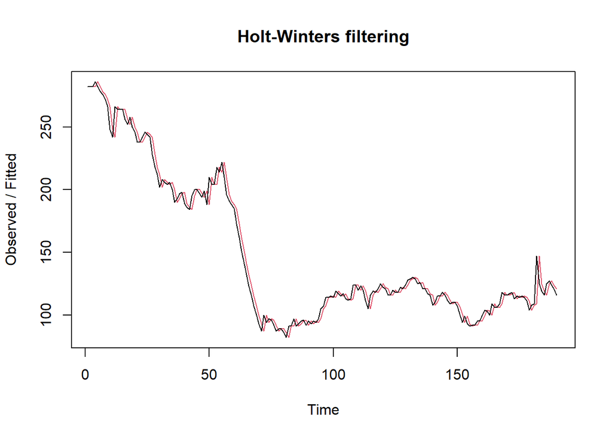

```r
plot(sesopt)
```

```r
#ramalan
ramalanopt<- forecast(sesopt, h=52)
ramalanopt
```

```
##     Point Forecast     Lo 80    Hi 80     Lo 95    Hi 95
## 191       116.0003 107.47167 124.5290 102.95688 129.0438
## 192       116.0003 103.93938 128.0613  97.55470 134.4459
## 193       116.0003 101.22891 130.7717  93.40939 138.5913
## 194       116.0003  98.94385 133.0568  89.91470 142.0859
## 195       116.0003  96.93067 135.0700  86.83581 145.1648
## 196       116.0003  95.11061 136.8900  84.05226 147.9484
## 197       116.0003  93.43689 138.5638  81.49253 150.5081
## 198       116.0003  91.87902 140.1216  79.10998 152.8907
## 199       116.0003  90.41585 141.5848  76.87224 155.1284
## 200       116.0003  89.03194 142.9687  74.75573 157.2449
## 201       116.0003  87.71566 144.2850  72.74266 159.2580
## 202       116.0003  86.45797 145.5427  70.81919 161.1815
## 203       116.0003  85.25168 146.7490  68.97433 163.0263
## 204       116.0003  84.09096 147.9097  67.19916 164.8015
```

[output cut: 38 more lines]

Setelah dilakukan peramalan, akan dilakukan perhitungan keakuratan hasil peramalan. Perhitungan akurasi ini dilakukan baik pada data latih dan data uji.

#### Akurasi Data Latih

Perhitungan akurasi data dapat dilakukan dengan cara langsung maupun manual. Secara langsung, nilai akurasi dapat diambil dari objek yang tersimpan pada hasil SES, yaitu *sum of squared errors* (SSE). Nilai akurasi lain dapat dihitung pula dari nilai SSE tersebut.

```r
#Keakuratan Metode
#Pada data training
SSE1<-ses1$SSE
MSE1<-ses1$SSE/length(train.ts)
RMSE1<-sqrt(MSE1)

akurasi1 <- matrix(c(SSE1,MSE1,RMSE1))
row.names(akurasi1)<- c("SSE", "MSE", "RMSE")
colnames(akurasi1) <- c("Akurasi lamda=0.2")
akurasi1
```

```
##      Akurasi lamda=0.2
## SSE        32132.59278
## MSE          169.11891
## RMSE          13.00457
```

```r
SSE2<-ses2$SSE
MSE2<-ses2$SSE/length(train.ts)
RMSE2<-sqrt(MSE2)

akurasi2 <- matrix(c(SSE2,MSE2,RMSE2))
row.names(akurasi2)<- c("SSE", "MSE", "RMSE")
colnames(akurasi2) <- c("Akurasi lamda=0.7")
akurasi2
```

```
##      Akurasi lamda=0.7
## SSE        9475.349709
## MSE          49.870262
## RMSE          7.061888
```

```r
#Cara Manual
fitted1<-ramalan1$fitted
sisaan1<-ramalan1$residuals
head(sisaan1)
```

```
## Time Series:
## Start = 1
## End = 6
## Frequency = 1
## [1]    NA  0.00  0.00  4.00 -0.80 -4.64
```

```r
resid1<-training$Close-ramalan1$fitted
head(resid1)
```

```
## Time Series:
## Start = 1
## End = 6
## Frequency = 1
## [1]    NA  0.00  0.00  4.00 -0.80 -4.64
```

```r
#Cara Manual
SSE.1=sum(sisaan1[2:length(train.ts)]^2)
SSE.1
```

```
## [1] 32132.59
```

```r
MSE.1 = SSE.1/length(train.ts)
MSE.1
```

```
## [1] 169.1189
```

```r
MAPE.1 = sum(abs(sisaan1[2:length(train.ts)]/train.ts[2:length(train.ts)])*
               100)/length(train.ts)
MAPE.1
```

```
## [1] 6.640157
```

```r
akurasi.1 <- matrix(c(SSE.1,MSE.1,MAPE.1))
row.names(akurasi.1)<- c("SSE", "MSE", "MAPE")
colnames(akurasi.1) <- c("Akurasi lamda=0.2")
akurasi.1
```

```
##      Akurasi lamda=0.2
## SSE       32132.592775
## MSE         169.118909
## MAPE          6.640157
```

```r
fitted2<-ramalan2$fitted
sisaan2<-ramalan2$residuals
head(sisaan2)
```

```
## Time Series:
## Start = 1
## End = 6
## Frequency = 1
## [1]    NA  0.00  0.00  4.00 -2.80 -4.84
```

```r
resid2<-training$Close-ramalan2$fitted
head(resid2)
```

```
## Time Series:
## Start = 1
## End = 6
## Frequency = 1
## [1]    NA  0.00  0.00  4.00 -2.80 -4.84
```

```r
SSE.2=sum(sisaan2[2:length(train.ts)]^2)
SSE.2
```

```
## [1] 9475.35
```

```r
MSE.2 = SSE.2/length(train.ts)
MSE.2
```

```
## [1] 49.87026
```

```r
MAPE.2 = sum(abs(sisaan2[2:length(train.ts)]/train.ts[2:length(train.ts)])*
               100)/length(train.ts)
MAPE.2
```

```
## [1] 3.535783
```

```r
akurasi.2 <- matrix(c(SSE.2,MSE.2,MAPE.2))
row.names(akurasi.2)<- c("SSE", "MSE", "MAPE")
colnames(akurasi.2) <- c("Akurasi lamda=0.7")
akurasi.2
```

```
##      Akurasi lamda=0.7
## SSE        9475.349709
## MSE          49.870262
## MAPE          3.535783
```

#### Akurasi Data Uji

Akurasi data uji dapat dihitung dengan cara yang hampir sama dengan perhitungan akurasi data latih.

```r
selisih1<-ramalan1$mean-testing$Close
SSEtesting1<-sum(selisih1^2)
MSEtesting1<-SSEtesting1/length(testing)

selisih2<-ramalan2$mean-testing$Close
SSEtesting2<-sum(selisih2^2)
MSEtesting2<-SSEtesting2/length(testing)

selisihopt<-ramalanopt$mean-testing$Close
SSEtestingopt<-sum(selisihopt^2)
MSEtestingopt<-SSEtestingopt/length(testing)

akurasitesting1 <- matrix(c(SSEtesting1,SSEtesting2,SSEtestingopt))
row.names(akurasitesting1)<- c("SSE1", "SSE2", "SSEopt")
akurasitesting1
```

```
##            [,1]
## SSE1   18509.23
## SSE2   14525.02
## SSEopt 12260.37
```

```r
akurasitesting2 <- matrix(c(MSEtesting1,MSEtesting2,MSEtestingopt))
row.names(akurasitesting2)<- c("MSE1", "MSE2", "MSEopt")
akurasitesting2
```

```
##            [,1]
## MSE1   2644.175
## MSE2   2075.002
## MSEopt 1751.482
```

Selain dengan cara di atas, perhitungan nilai akurasi dapat menggunakan fungsi `accuracy()` dari *package* `forecast` . Penggunaannya yaitu dengan menuliskan `accuracy(hasil ramalan, kondisi aktual)` . Contohnya adalah sebagai berikut.

```r
#cara lain
accuracy(ramalanopt,testing$Close)
```

```
##                      ME      RMSE       MAE         MPE      MAPE     MASE
## Training set  -0.878362  6.695179  4.656129  -0.5809181  3.331511 1.000009
## Test set     -11.077246 15.355012 11.384877 -11.7931077 12.054368 2.445161
##                     ACF1
## Training set -0.01244396
## Test set              NA
```

### DES

Metode pemulusan *Double Exponential Smoothing* (DES) digunakan untuk data yang memiliki pola tren. Metode DES adalah metode semacam SES, hanya saja dilakukan dua kali, yaitu pertama untuk tahapan ‘level’ dan kedua untuk tahapan ‘tren’. Pemulusan menggunakan metode ini akan menghasilkan peramalan tidak konstan untuk periode berikutnya.

Pemulusan dengan metode DES kali ini akan menggunakan fungsi `HoltWinters()` . Jika sebelumnya nilai argumen `beta` dibuat `FALSE` , kali ini argumen tersebut akan diinisialisasi bersamaan dengan nilai `alpha` .

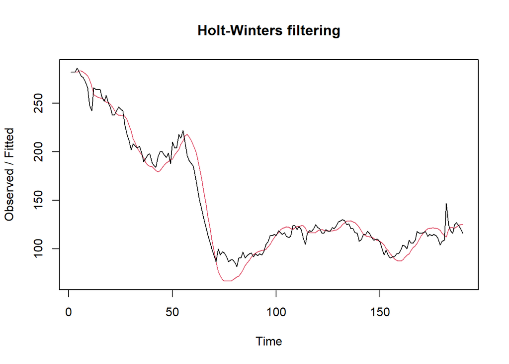

```r
#Lamda=0.2 dan gamma=0.2
des.1<- HoltWinters(train.ts, gamma = FALSE, beta = 0.2, alpha = 0.2)
plot(des.1)
```

```r
#ramalan
ramalandes1<- forecast(des.1, h=52)
ramalandes1
```

```
##     Point Forecast       Lo 80    Hi 80      Lo 95    Hi 95
## 191       123.5693 108.7493109 138.3892 100.904103 146.2344
## 192       123.8793 108.6384740 139.1201 100.570487 147.1880
## 193       124.1893 108.3936737 139.9849 100.031992 148.3465
## 194       124.4993 108.0071204 140.9914  99.276705 149.7218
## 195       124.8093 107.4756296 142.1429  98.299755 151.3188
## 196       125.1193 106.7999919 143.4386  97.102351 153.1362
## 197       125.4293 105.9840547 144.8745  95.690377 155.1682
## 198       125.7393 105.0337332 146.4448  94.072880 157.4057
## 199       126.0493 103.9561187 148.1424  92.260706 159.8379
## 200       126.3593 102.7587732 149.9598  90.265419 162.4531
## 201       126.6693 101.4492298 151.8893  88.098540 165.2400
## 202       126.9793 100.0346773 153.9239  85.771063 168.1875
## 203       127.2893  98.5217846 156.0568  83.293188 171.2854
## 204       127.5993  96.9166255 158.2820  80.674204 174.5244
```

[output cut: 38 more lines]

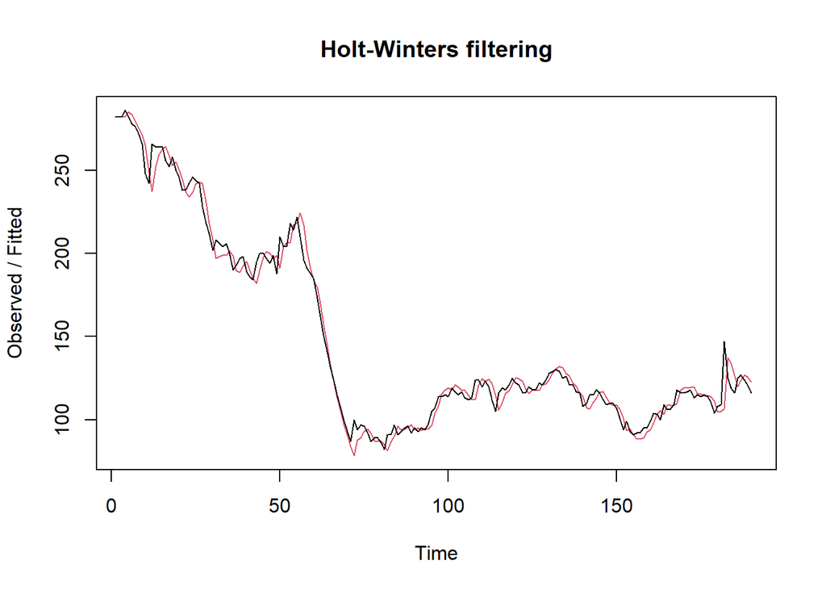

```r
#Lamda=0.6 dan gamma=0.3
des.2<- HoltWinters(train.ts, gamma = FALSE, beta = 0.3, alpha = 0.6)
plot(des.2)
```

```r
#ramalan
ramalandes2<- forecast(des.2, h=52)
ramalandes2
```

```
##     Point Forecast       Lo 80    Hi 80       Lo 95    Hi 95
## 191      117.29156  108.111378 126.4717  103.251683 131.3314
## 192      115.89492  104.252360 127.5375   98.089163 133.7007
## 193      114.49827   99.896298 129.1002   92.166480 136.8301
## 194      113.10163   95.136595 131.0667   85.626481 140.5768
## 195      111.70498   90.035086 133.3749   78.563735 144.8462
## 196      110.30834   84.633354 135.9833   71.041837 149.5748
## 197      108.91170   78.960656 138.8627   63.105533 154.7179
## 198      107.51505   73.038608 141.9915   54.787881 160.2422
## 199      106.11841   66.883893 145.3529   46.114396 166.1224
## 200      104.72176   60.509867 148.9337   37.105504 172.3380
## 201      103.32512   53.927548 152.7227   27.778054 178.8722
## 202      101.92847   47.146241 156.7107   18.146279 185.7107
## 203      100.53183   40.173964 160.8897    8.222440 192.8412
## 204       99.13519   33.017731 165.2526   -1.982735 200.2531
```

[output cut: 38 more lines]

Selanjutnya jika ingin membandingkan plot data latih dan data uji adalah sebagai berikut.

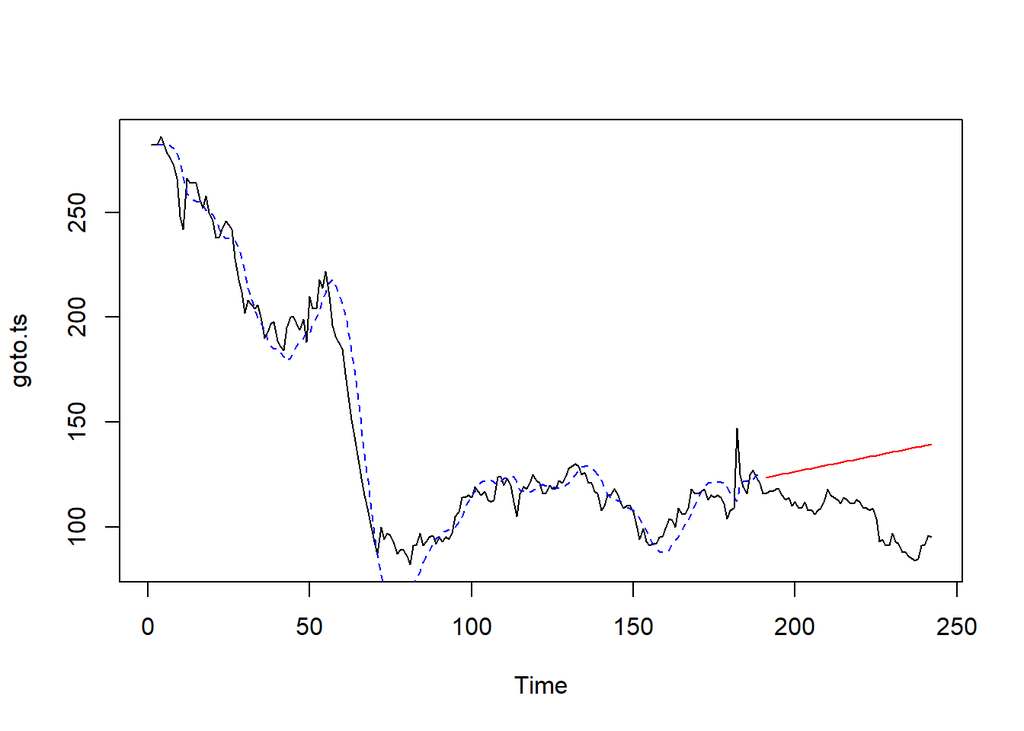

```r
#Visually evaluate the prediction
plot(goto.ts)
lines(des.1$fitted[,1], lty=2, col="blue")
lines(ramalandes1$mean, col="red")
```

Untuk mendapatkan nilai parameter optimum dari DES, argumen `alpha` dan `beta` dapat dibuat `NULL` seperti berikut.

```r
#Lamda dan gamma optimum
des.opt<- HoltWinters(train.ts, gamma = FALSE)
des.opt
```

```
## Holt-Winters exponential smoothing with trend and without seasonal component.
##
## Call:
## HoltWinters(x = train.ts, gamma = FALSE)
##
## Smoothing parameters:
##  alpha: 0.9778382
##  beta : 0.02328053
##  gamma: FALSE
##
## Coefficients:
##           [,1]
## a 116.11361545
## b  -0.06094804
```

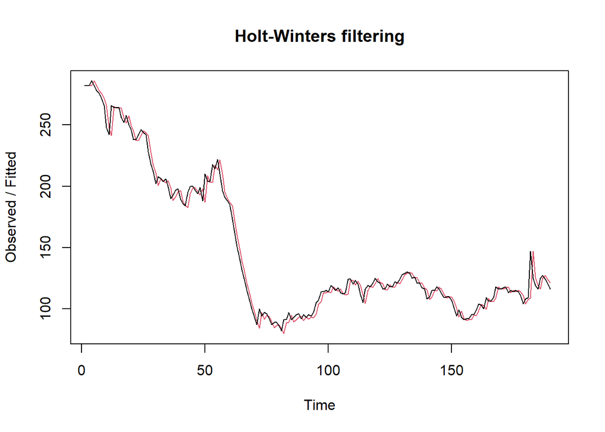

```r
plot(des.opt)
```

```r
#ramalan
ramalandesopt<- forecast(des.opt, h=52)
ramalandesopt
```

```
##     Point Forecast     Lo 80    Hi 80      Lo 95    Hi 95
## 191       116.0527 107.45322 124.6521 102.900943 129.2044
## 192       115.9917 103.82659 128.1568  97.386765 134.5967
## 193       115.9308 100.91620 130.9453  92.967970 138.8936
## 194       115.8698  98.36645 133.3732  89.100719 142.6389
## 195       115.8089  96.03870 135.5790  85.573009 146.0447
## 196       115.7479  93.86213 137.6337  82.276483 149.2194
## 197       115.6870  91.79491 139.5790  79.147218 152.2267
## 198       115.6260  89.81007 141.4420  76.143928 155.1081
## 199       115.5651  87.88903 143.2411  73.238213 157.8920
## 200       115.5041  86.01841 144.9899  70.409614 160.5987
## 201       115.4432  84.18823 146.6981  67.642859 163.2435
## 202       115.3822  82.39082 148.3737  64.926221 165.8383
## 203       115.3213  80.62016 150.0224  62.250485 168.3921
## 204       115.2603  78.87141 151.6493  59.608276 170.9124
```

[output cut: 38 more lines]

Selanjutnya akan dilakukan perhitungan akurasi pada data latih maupun data uji dengan ukuran akurasi SSE, MSE dan MAPE.

#### Akurasi Data Latih

```r
#Akurasi Data Training
ssedes.train1<-des.1$SSE
msedes.train1<-ssedes.train1/length(train.ts)
sisaandes1<-ramalandes1$residuals
head(sisaandes1)
```

```
## Time Series:
## Start = 1
## End = 6
## Frequency = 1
## [1]      NA      NA  0.0000  4.0000 -0.9600 -4.8896
```

```r
mapedes.train1 <- sum(abs(sisaandes1[4:length(train.ts)]/train.ts[4:length(train.ts)])
                      *100)/length(train.ts)

akurasides.1 <- matrix(c(ssedes.train1,msedes.train1,mapedes.train1))
row.names(akurasides.1)<- c("SSE", "MSE", "MAPE")
colnames(akurasides.1) <- c("Akurasi lamda=0.2 dan gamma=0.2")
akurasides.1
```

```
##      Akurasi lamda=0.2 dan gamma=0.2
## SSE                     25007.395370
## MSE                       131.617870
## MAPE                        6.455949
```

```r
ssedes.train2<-des.2$SSE
msedes.train2<-ssedes.train2/length(train.ts)
sisaandes2<-ramalandes2$residuals
head(sisaandes2)
```

```
## Time Series:
## Start = 1
## End = 6
## Frequency = 1
## [1]      NA      NA  0.0000  4.0000 -3.1200 -5.4064
```

```r
mapedes.train2 <- sum(abs(sisaandes2[4:length(train.ts)]/train.ts[4:length(train.ts)])
                      *100)/length(train.ts)

akurasides.2 <- matrix(c(ssedes.train2,msedes.train2,mapedes.train2))
row.names(akurasides.2)<- c("SSE", "MSE", "MAPE")
colnames(akurasides.2) <- c("Akurasi lamda=0.6 dan gamma=0.3")
akurasides.2
```

```
##      Akurasi lamda=0.6 dan gamma=0.3
## SSE                      9595.918220
## MSE                        50.504833
## MAPE                        3.554792
```

Hasil akurasi dari data latih didapatkan skenario 2 dengan lamda=0.6 dan gamma=0.3 memiliki hasil yang lebih baik. Namun untuk kedua skenario dapat dikategorikan peramalan sangat baik berdasarkan nilai MAPE-nya.

#### Akurasi Data Uji

```r
#Akurasi Data Testing
selisihdes1<-ramalandes1$mean-testing$Close
selisihdes1
```

```
## Time Series:
## Start = 191
## End = 242
## Frequency = 1
##  [1]  7.569261  6.879263  7.189266  6.499268  6.809270 10.119273 12.429275
##  [8] 11.739277 16.049279 14.359282 17.669284 17.979286 15.289289 19.599291
## [15] 19.909293 22.219296 20.529298 19.839300 16.149303 11.459305 14.769307
## [22] 16.079310 17.389312 19.699314 17.009317 18.319319 20.629321 20.939324
## [29] 19.249326 20.559328 23.869331 24.179333 25.489335 24.799337 30.109340
## [36] 41.419342 40.729344 44.039347 44.349349 38.659351 42.969354 44.279356
## [43] 48.589358 48.899361 51.209363 52.519365 53.829368 53.139370 47.449372
## [50] 47.759375 43.069377 44.379379
```

```r
SSEtestingdes1<-sum(selisihdes1^2)
MSEtestingdes1<-SSEtestingdes1/length(testing$Close)
MAPEtestingdes1<-sum(abs(selisihdes1/testing$Close)*100)/length(testing$Close)

selisihdes2<-ramalandes2$mean-testing$Close
selisihdes2
```

```
## Time Series:
## Start = 191
## End = 242
## Frequency = 1
##  [1]   1.291560  -1.105084  -2.501728  -4.898372  -6.295017  -4.691661
##  [7]  -4.088305  -6.484949  -3.881593  -7.278237  -5.674882  -7.071526
## [13] -11.468170  -8.864814 -10.261458  -9.658103 -13.054747 -15.451391
## [19] -20.848035 -27.244679 -25.641323 -26.037968 -26.434612 -25.831256
## [25] -30.227900 -30.624544 -30.021188 -31.417833 -34.814477 -35.211121
## [31] -33.607765 -35.004409 -35.401053 -37.797698 -34.194342 -24.590986
## [37] -26.987630 -25.384274 -26.780919 -34.177563 -31.574207 -31.970851
## [43] -29.367495 -30.764139 -30.160784 -30.557428 -30.954072 -33.350716
## [49] -40.747360 -42.144004 -48.540649 -48.937293
```

```r
SSEtestingdes2<-sum(selisihdes2^2)
MSEtestingdes2<-SSEtestingdes2/length(testing$Close)
MAPEtestingdes2<-sum(abs(selisihdes2/testing$Close)*100)/length(testing$Close)

selisihdesopt<-ramalandesopt$mean-testing$Close
selisihdesopt
```

```
## Time Series:
## Start = 191
## End = 242
## Frequency = 1
##  [1]  0.0526674 -1.0082806 -1.0692287 -2.1301767 -2.1911248  0.7479272
##  [7]  2.6869791  1.6260311  5.5650831  3.5041350  6.4431870  6.3822389
## [13]  3.3212909  7.2603428  7.1993948  9.1384468  7.0774987  6.0165507
## [19]  1.9556026 -3.1053454 -0.1662935  0.7727585  1.7118105  3.6508624
## [25]  0.5899144  1.5289663  3.4680183  3.4070702  1.3461222  2.2851742
## [31]  5.2242261  5.1632781  6.1023300  5.0413820  9.9804339 20.9194859
## [37] 19.8585379 22.7975898 22.7366418 16.6756937 20.6147457 21.5537976
## [43] 25.4928496 25.4319016 27.3709535 28.3100055 29.2490574 28.1881094
## [49] 22.1271613 22.0662133 17.0052653 17.9443172
```

```r
SSEtestingdesopt<-sum(selisihdesopt^2)
MSEtestingdesopt<-SSEtestingdesopt/length(testing$Close)
MAPEtestingdesopt<-sum(abs(selisihdesopt/testing$Close)*100)/length(testing$Close)

akurasitestingdes <-
  matrix(c(SSEtestingdes1,MSEtestingdes1,MAPEtestingdes1,SSEtestingdes2,MSEtestingdes2,
           MAPEtestingdes2,SSEtestingdesopt,MSEtestingdesopt,MAPEtestingdesopt),
         nrow=3,ncol=3)
row.names(akurasitestingdes)<- c("SSE", "MSE", "MAPE")
colnames(akurasitestingdes) <- c("des ske1","des ske2","des opt")
akurasitestingdes
```

```
##         des ske1    des ske2    des opt
## SSE  48022.32372 37189.86984 9834.07884
## MSE    923.50623   715.18980  189.11690
## MAPE    27.11527    23.17244   10.58118
```

#### Perbandingan SES dan DES

```r
MSEfull <-
  matrix(c(MSEtesting1,MSEtesting2,MSEtestingopt,MSEtestingdes1,MSEtestingdes2,
           MSEtestingdesopt),nrow=3,ncol=2)
row.names(MSEfull)<- c("ske 1", "ske 2", "ske opt")
colnames(MSEfull) <- c("ses","des")
MSEfull
```

```
##              ses      des
## ske 1   2644.175 923.5062
## ske 2   2075.002 715.1898
## ske opt 1751.482 189.1169
```

Kedua metode dapat dibandingkan dengan menggunakan ukuran akurasi yang sama. Contoh di atas adalah perbandingan kedua metode dengan ukuran akurasi MSE. Hasilnya didapatkan metode DES lebih baik dibandingkan metode SES dilihat dari MSE yang lebih kecil nilainya.